# Ağaç Bazlı Yöntemler

(İktisatçılar İçin) Makine Öğrenmesi (TEK-ES-2021)

Prof. Dr. Hüseyin Taştan

Yıldız Teknik Üniversitesi

Haziran 2021

# 1 R ile Sınıflandırma Ağaçları

`R`’da ağaç tahmini için çok sayıda paket vardır. Bunlardan biri hem regresyon hem de sınıflama ağaçlarının tahminini yapan `tree` paketidir. Burada örnek olarak `Carseats` veri setini kullanacağız. `Sales` değişkeni 8 değeri kullanılarak ikili kategorik değişkene dönüştürülmüştür:

```r
library(tree)
library(ISLR)
attach(Carseats)
Carseats$High <- factor(ifelse(Carseats$Sales<=8,"No","Yes"))
```

`High` Satışlar 8’den büyükse “Yes” (1) değilse “No” (0) değerini almaktadır.

`Sales` değişkenini dışlayarak diğer tüm değişkenlerle `High` için bir ağaç tahmin edelim:

```r
tree.carseats <- tree(High ~ . -Sales, data = Carseats)
summary(tree.carseats)
```

```
##
## Classification tree:
## tree(formula = High ~ . - Sales, data = Carseats)
## Variables actually used in tree construction:
## [1] "ShelveLoc"   "Price"       "Income"      "CompPrice"   "Population"
## [6] "Advertising" "Age"         "US"
## Number of terminal nodes:  27
## Residual mean deviance:  0.4575 = 170.7 / 373
## Misclassification error rate: 0.09 = 36 / 400
```

Eğitim hata oranı %9 olarak bulunmuştur (misclassification error rate).

Tahmin edilen ağacın yaprak sayısı 27’dir (terminal node):

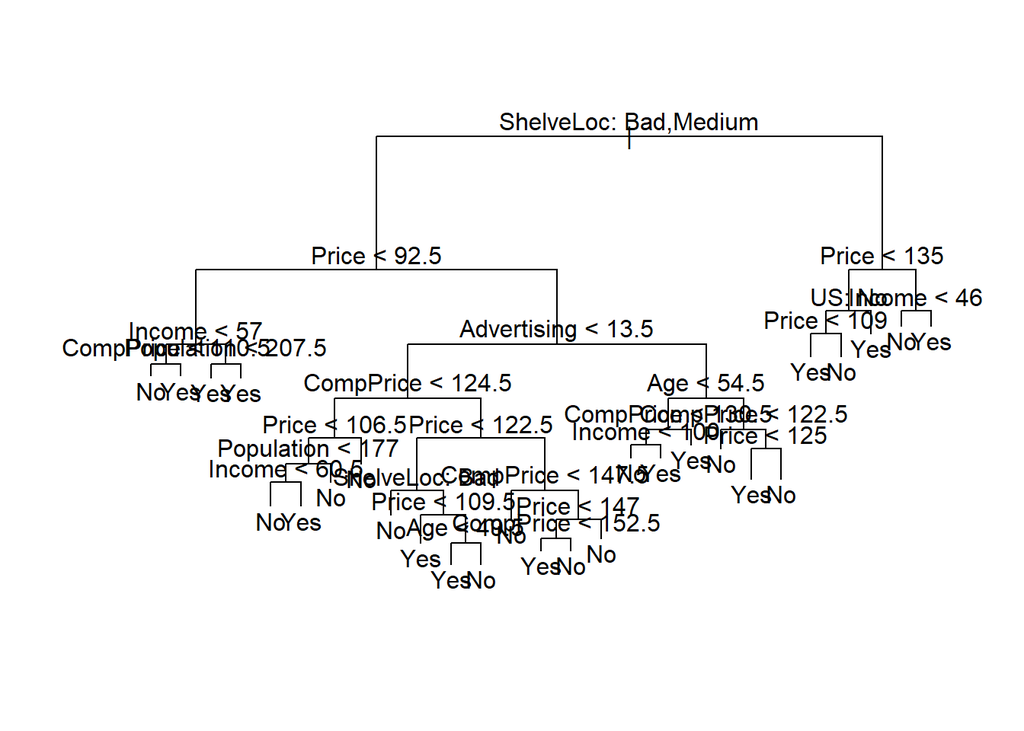

```r
plot(tree.carseats)
text(tree.carseats, pretty=0)
```

Satışların yüksekliğini etkileyen en önemli değişken raf yeridir (`ShelveLoc`, **B**ad, **G**ood, **M**edium). İlk düğümde Kötü ve Orta kalitedeki raf lokasyonları İyi raf lokasyonundan ayrılmaktadır.

Ağacın tüm detayları:

```r
tree.carseats
```

```
## node), split, n, deviance, yval, (yprob)
##       * denotes terminal node
##
##   1) root 400 541.500 No ( 0.59000 0.41000 )
##     2) ShelveLoc: Bad,Medium 315 390.600 No ( 0.68889 0.31111 )
##       4) Price < 92.5 46  56.530 Yes ( 0.30435 0.69565 )
##         8) Income < 57 10  12.220 No ( 0.70000 0.30000 )
##          16) CompPrice < 110.5 5   0.000 No ( 1.00000 0.00000 ) *
##          17) CompPrice > 110.5 5   6.730 Yes ( 0.40000 0.60000 ) *
##         9) Income > 57 36  35.470 Yes ( 0.19444 0.80556 )
##          18) Population < 207.5 16  21.170 Yes ( 0.37500 0.62500 ) *
##          19) Population > 207.5 20   7.941 Yes ( 0.05000 0.95000 ) *
##       5) Price > 92.5 269 299.800 No ( 0.75465 0.24535 )
##        10) Advertising < 13.5 224 213.200 No ( 0.81696 0.18304 )
##          20) CompPrice < 124.5 96  44.890 No ( 0.93750 0.06250 )
##            40) Price < 106.5 38  33.150 No ( 0.84211 0.15789 )
##              80) Population < 177 12  16.300 No ( 0.58333 0.41667 )
##               160) Income < 60.5 6   0.000 No ( 1.00000 0.00000 ) *
##               161) Income > 60.5 6   5.407 Yes ( 0.16667 0.83333 ) *
##              81) Population > 177 26   8.477 No ( 0.96154 0.03846 ) *
##            41) Price > 106.5 58   0.000 No ( 1.00000 0.00000 ) *
##          21) CompPrice > 124.5 128 150.200 No ( 0.72656 0.27344 )
##            42) Price < 122.5 51  70.680 Yes ( 0.49020 0.50980 )
##              84) ShelveLoc: Bad 11   6.702 No ( 0.90909 0.09091 ) *
##              85) ShelveLoc: Medium 40  52.930 Yes ( 0.37500 0.62500 )
##               170) Price < 109.5 16   7.481 Yes ( 0.06250 0.93750 ) *
##               171) Price > 109.5 24  32.600 No ( 0.58333 0.41667 )
##                 342) Age < 49.5 13  16.050 Yes ( 0.30769 0.69231 ) *
##                 343) Age > 49.5 11   6.702 No ( 0.90909 0.09091 ) *
##            43) Price > 122.5 77  55.540 No ( 0.88312 0.11688 )
##              86) CompPrice < 147.5 58  17.400 No ( 0.96552 0.03448 ) *
##              87) CompPrice > 147.5 19  25.010 No ( 0.63158 0.36842 )
##               174) Price < 147 12  16.300 Yes ( 0.41667 0.58333 )
##                 348) CompPrice < 152.5 7   5.742 Yes ( 0.14286 0.85714 ) *
##                 349) CompPrice > 152.5 5   5.004 No ( 0.80000 0.20000 ) *
##               175) Price > 147 7   0.000 No ( 1.00000 0.00000 ) *
##        11) Advertising > 13.5 45  61.830 Yes ( 0.44444 0.55556 )
##          22) Age < 54.5 25  25.020 Yes ( 0.20000 0.80000 )
##            44) CompPrice < 130.5 14  18.250 Yes ( 0.35714 0.64286 )
##              88) Income < 100 9  12.370 No ( 0.55556 0.44444 ) *
##              89) Income > 100 5   0.000 Yes ( 0.00000 1.00000 ) *
##            45) CompPrice > 130.5 11   0.000 Yes ( 0.00000 1.00000 ) *
##          23) Age > 54.5 20  22.490 No ( 0.75000 0.25000 )
##            46) CompPrice < 122.5 10   0.000 No ( 1.00000 0.00000 ) *
##            47) CompPrice > 122.5 10  13.860 No ( 0.50000 0.50000 )
##              94) Price < 125 5   0.000 Yes ( 0.00000 1.00000 ) *
##              95) Price > 125 5   0.000 No ( 1.00000 0.00000 ) *
##     3) ShelveLoc: Good 85  90.330 Yes ( 0.22353 0.77647 )
##       6) Price < 135 68  49.260 Yes ( 0.11765 0.88235 )
##        12) US: No 17  22.070 Yes ( 0.35294 0.64706 )
##          24) Price < 109 8   0.000 Yes ( 0.00000 1.00000 ) *
##          25) Price > 109 9  11.460 No ( 0.66667 0.33333 ) *
##        13) US: Yes 51  16.880 Yes ( 0.03922 0.96078 ) *
##       7) Price > 135 17  22.070 No ( 0.64706 0.35294 )
##        14) Income < 46 6   0.000 No ( 1.00000 0.00000 ) *
##        15) Income > 46 11  15.160 Yes ( 0.45455 0.54545 ) *
```

Test hata oranı:

```r
set.seed(2)
train <- sample(1:nrow(Carseats), 200)
Carseats.test <- Carseats[-train,]
High.test <- Carseats$High[-train]
tree.carseats <- tree(High ~ . -Sales, Carseats, subset=train)
tree.pred <- predict(tree.carseats, Carseats.test, type="class")
table(tree.pred, High.test)
```

```
##          High.test
## tree.pred  No Yes
##       No  104  33
##       Yes  13  50
```

```r
# correct prediction rate
(104+50)/200
```

```
## [1] 0.77
```

Ağacın çapraz geçerleme ile budanması, `cv.tree()` fonksiyonu:

```r
set.seed(11)
cv.carseats <- cv.tree(tree.carseats, FUN=prune.misclass)
names(cv.carseats)
```

```
## [1] "size"   "dev"    "k"      "method"
```

```r
cv.carseats
```

```
## $size
## [1] 21 19 14  9  8  5  3  2  1
##
## $dev
## [1] 79 79 77 76 74 75 79 76 82
##
## $k
## [1] -Inf  0.0  1.0  1.4  2.0  3.0  4.0  9.0 18.0
##
## $method
## [1] "misclass"
##
## attr(,"class")
## [1] "prune"         "tree.sequence"
```

Yukarıdaki çıktıda, `dev` çapraz geçerleme hatasını, `k` ayarlama parametresi $\alpha$’yı ve `size` ağacın büyüklüğünü (terminal düğüm sayısı) göstermektedir. En küçük çapraz geçerleme hatası 74’dür ve yaprak sayısı 8 olan bir ağaca karşılık gelmektedir.

Ağaç büyüklüğü ve k (cost-complexity parameter)’ye göre hata oranının grafikleri:

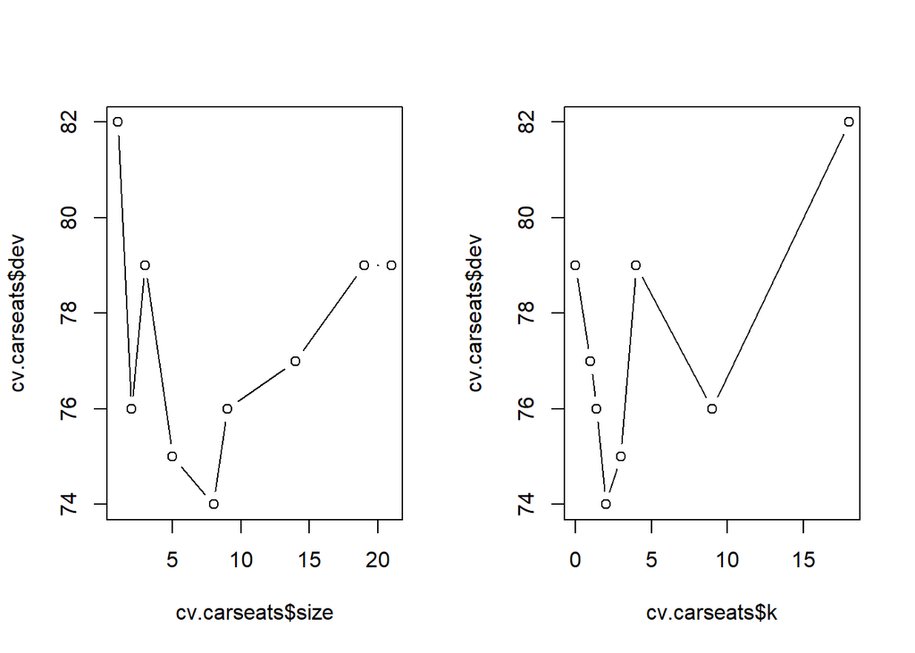

```r
par(mfrow=c(1,2))
plot(cv.carseats$size, cv.carseats$dev, type="b")
plot(cv.carseats$k, cv.carseats$dev, type="b")
```

Şimdi `prune.misclass()` fonksiyonunu kullanarak ağacı budayabiliriz:

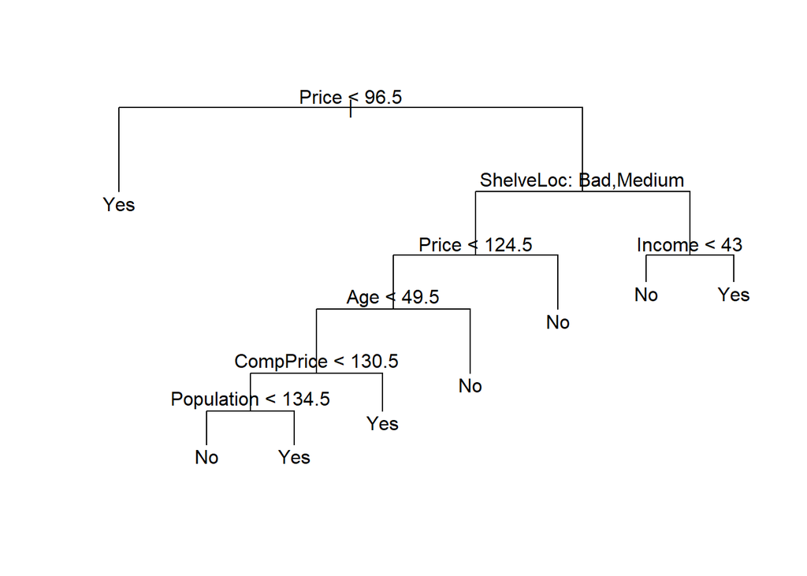

```r
prune.carseats <- prune.misclass(tree.carseats, best=8)
plot(prune.carseats)
text(prune.carseats, pretty=0)
```

Not: kitapta 9 yapraklı bir ağaç tahmin edilmiştir:

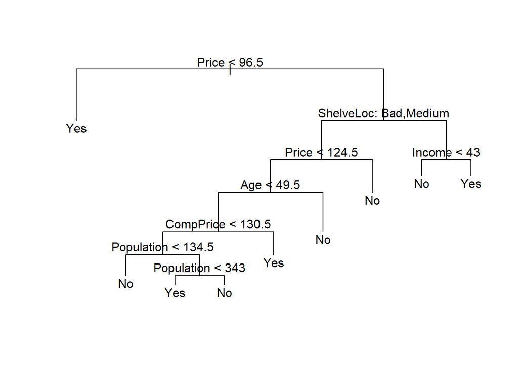

```r
prune.carseats <- prune.misclass(tree.carseats, best=9)
plot(prune.carseats)
text(prune.carseats,pretty=0)
```

Budanmış ağacın kestirim performansı nasıldır? `predict()` fonksiyonuyla sınıflandırma hatasını tahmin edelim:

```r
tree.pred <- predict(prune.carseats, Carseats.test, type="class")
table(tree.pred, High.test)
```

```
##          High.test
## tree.pred No Yes
##       No  97  25
##       Yes 20  58
```

```r
(97+58)/200
```

```
## [1] 0.775
```

# 2 R ile Regresyon Ağaçları

Örnek olarak `MASS` paketinde yer alan `Boston` ev fiyatları verisini kullanacağız. Bağımlı değişken medyan ev fiyatları (`medv`). Eğitim verilerinde ağaç tahmini:

```r
library(MASS)
library(tree)
set.seed(81)
train <- sample(1:nrow(Boston), nrow(Boston)/2)
tree_boston <- tree(medv ~ .,
                    data = Boston,
                    subset = train)
summary(tree_boston)
```

```
##
## Regression tree:
## tree(formula = medv ~ ., data = Boston, subset = train)
## Variables actually used in tree construction:
## [1] "lstat" "rm"    "age"   "nox"   "crim"
## Number of terminal nodes:  8
## Residual mean deviance:  14.56 = 3568 / 245
## Distribution of residuals:
##     Min.  1st Qu.   Median     Mean  3rd Qu.     Max.
## -14.5300  -1.7920  -0.1923   0.0000   1.9080  12.1700
```

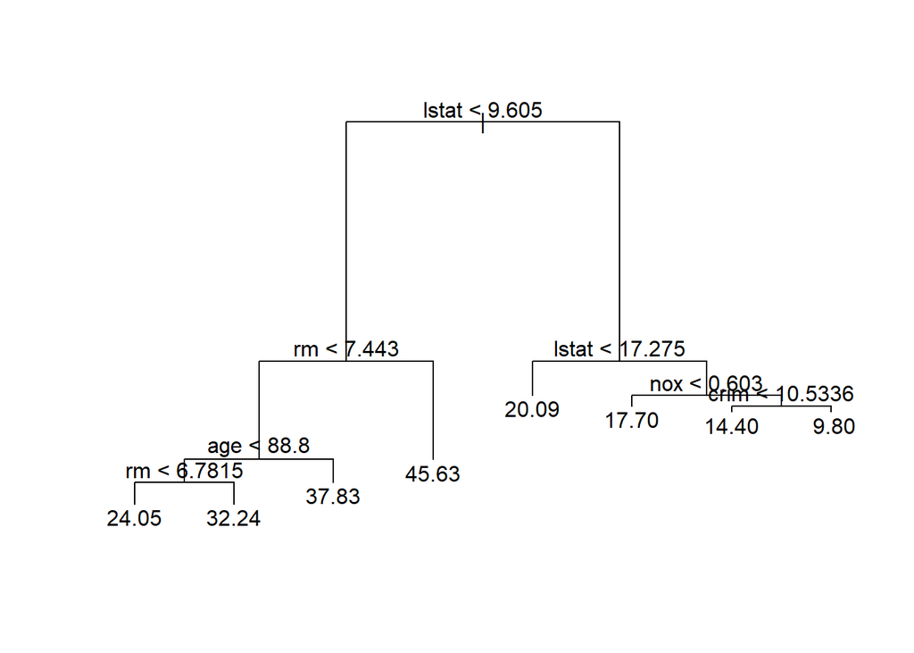

```r
plot(tree_boston)
text(tree_boston, pretty=0)
```

`lstat`: sosyoekonomik statüsü düşük olan hanelerin oranı. Bu değişkenin düşük olduğu yerlerde evler daha pahalıdır.

Ağacın budanması:

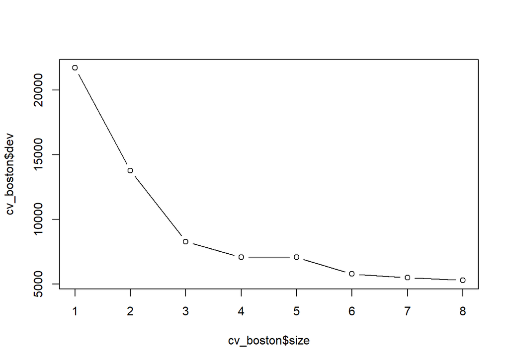

```r
cv_boston <- cv.tree(tree_boston)
plot(cv_boston$size, cv_boston$dev, type='b')
```

Çapraz geçerleme en karmaşık ağacı seçti. Yine de ağacı budamak istersek `prune.tree()` fonksiyonunu kullanabiliriz:

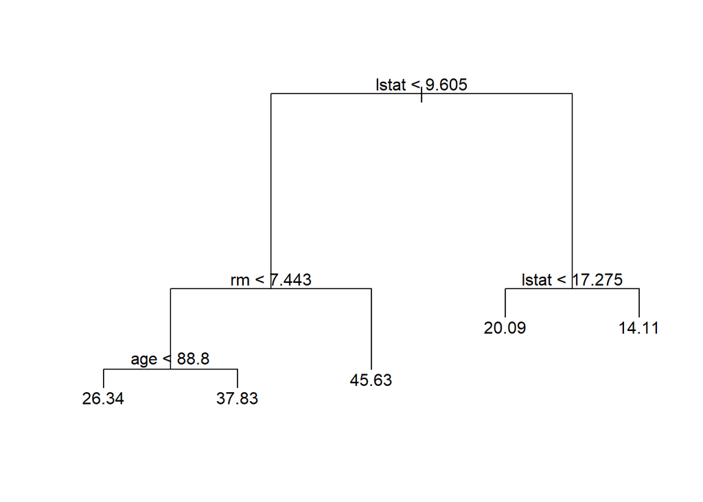

```r
prune_boston <- prune.tree(tree_boston, best=5)
plot(prune_boston)
text(prune_boston, pretty=0)
```

Budanmamış ağaç üzerinden test hatasının tahmini:

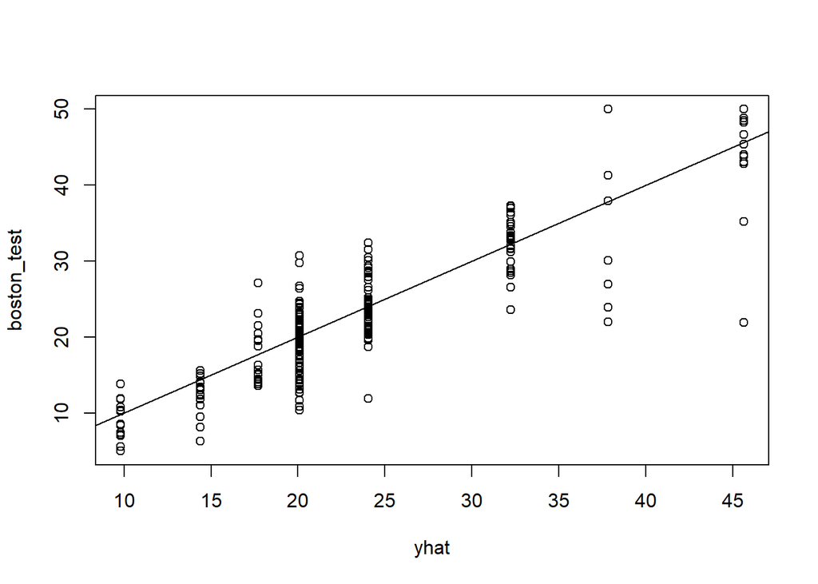

```r
yhat <- predict(tree_boston, newdata = Boston[-train,])
boston_test <- Boston[-train, "medv"]
plot(yhat, boston_test)
abline(0,1)
```

```r
mean((yhat - boston_test)^2)
```

```
## [1] 18.92867
```

Test MSE = 18.93.

# 3 Bagging ve Rassal Ormanlar

Örnek veri seti = `Boston`.

Bagging ve rassal ormanlar için R `randomForest` paketi kullanılabilir. Bagging rassal ormanların özel bir halidir (m = p).

Bagging tahmini:

```r
library(randomForest)
set.seed(1)
bag_boston <- randomForest(medv ~ .,
                           data = Boston,
                           subset = train,
                           mtry = 13,
                           importance = TRUE
                           )
bag_boston
```

```
##
## Call:
##  randomForest(formula = medv ~ ., data = Boston, mtry = 13, importance = TRUE,      subset = train)
##                Type of random forest: regression
##                      Number of trees: 500
## No. of variables tried at each split: 13
##
##           Mean of squared residuals: 12.05315
##                     % Var explained: 85.87
```

`mtry=13` ayarlanma parametresi = 13 değişkenin tamamı her ayırımda dikkate alınacak (bagging). Modelin test setindeki performansı:

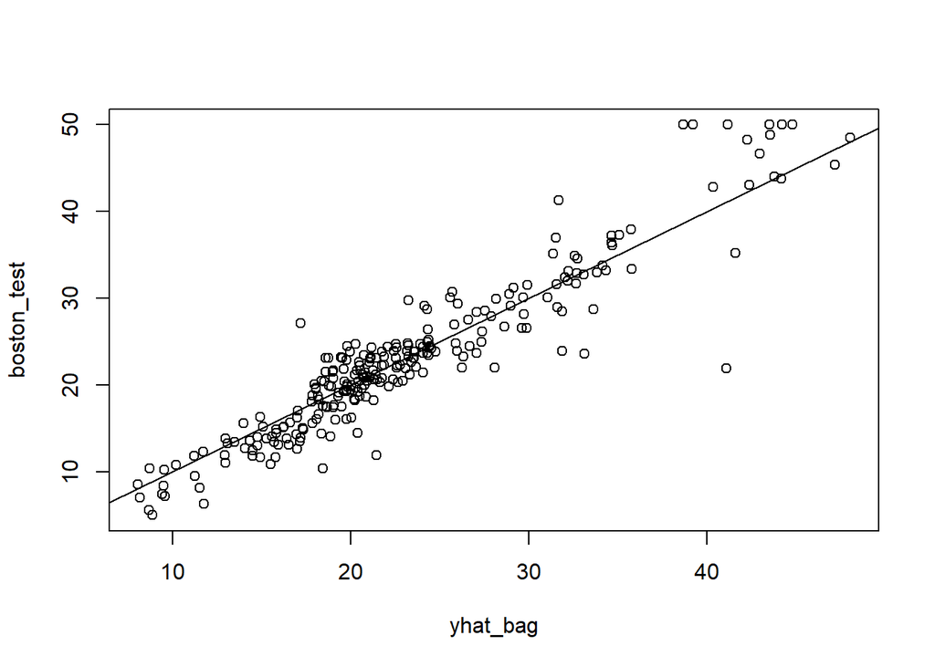

```r
yhat_bag <- predict(bag_boston, newdata = Boston[-train,])
plot(yhat_bag, boston_test)
abline(0,1)
```

```r
mean((yhat_bag - boston_test)^2)
```

```
## [1] 10.13872
```

Test MSE = 10.13872.

```r
bag_boston <- randomForest(medv ~ .,
                           data = Boston,
                           subset = train,
                           mtry = 13,
                           ntree = 25)
yhat_bag <- predict(bag_boston, newdata = Boston[-train,])
mean((yhat_bag - boston_test)^2)
```

```
## [1] 10.39242
```

Rassal orman tahmini de benzer adımlara sahiptir. Ancak bu durumda daha küçük bir `mtry` değeri kullanırız. Default olarak `randomForest()` fonksiyonu $p/3$ değişkeni kullanır (sınıflama için $\sqrt{p}$). Aşağıda `mtry = 6` kullanılmıştır:

```r
# random forest prediction
set.seed(1)
rf_boston <- randomForest(medv ~ .,
                          data = Boston,
                          subset = train,
                          mtry=6,
                          importance = TRUE)
yhat_rf <- predict(rf_boston, newdata = Boston[-train,])
mean((yhat_rf - boston_test)^2)
```

```
## [1] 10.09993
```

Rassal ormanlar küçük de olsa daha iyi bir test başarısı sergiledi.

`importance()` fonksiyonunu kullanarak her bir değişkenin önem düzeyini görebiliriz:

```r
importance(rf_boston)
```

```
##           %IncMSE IncNodePurity
## crim    12.369627    1181.71107
## zn       1.989412      39.94276
## indus    8.207374     647.08437
## chas     1.969458      94.36769
## nox     16.087308     970.88334
## rm      32.320815    6515.37020
## age      9.266499     512.38643
## dis     15.564389    1630.27794
## rad      5.241457     131.56836
## tax      8.947064     546.01280
## ptratio 10.734024     997.05756
## black    6.323236     352.36805
## lstat   28.364019    7465.77705
```

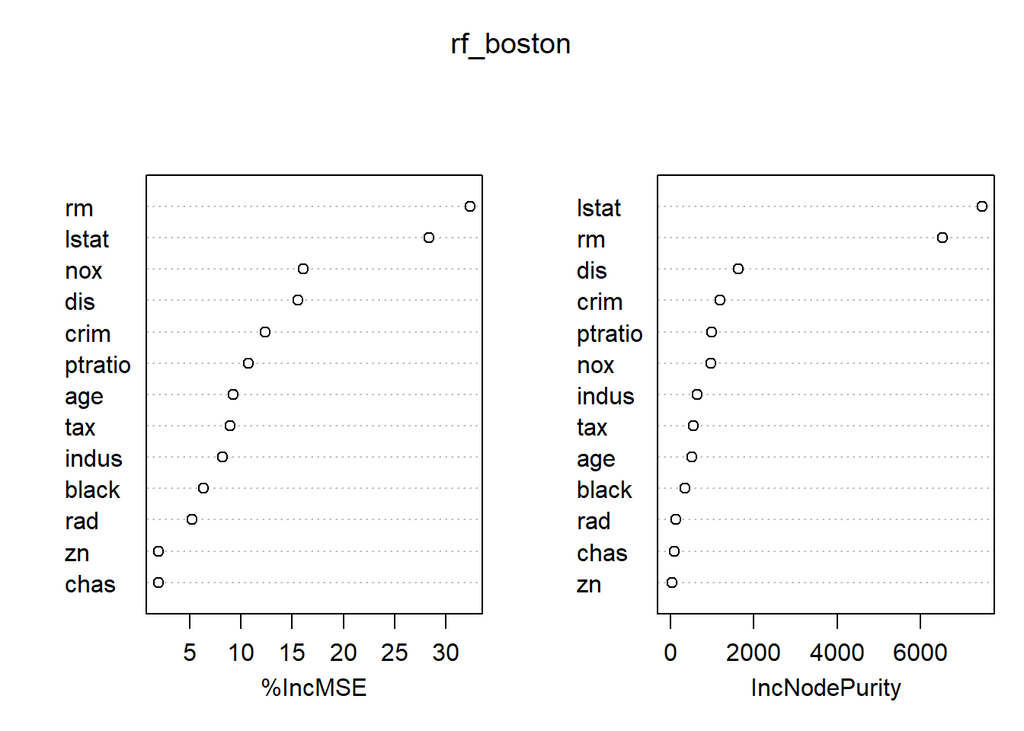

```r
varImpPlot(rf_boston)
```

Sonuçlara göre bölgenin refah düzeyi (`lstat`) ve ev büyüklüğü (`rm`) en önemli değişkenlerdir.

# 4 Boosting

## 4.1 `{gbm}` Paketi

Boosting (takviye) yöntemi için `{gbm}` paketindeki `gbm()` fonksiyonu kullanılabilir (bkz. https://www.rdocumentation.org/packages/gbm/versions/2.1.8).

Örnek olarak `Boston` veri seti için bir takviyeli ağaç tahmin edelim. Bunun için `gbm()` fonksiyonunu `distribution="gaussian"` opsiyonu ile çalıştıracağız (regresyon problemi olduğu için). İkili sınıflama problemleri için `distribution="bernoulli"` kullanılabilir. `n.trees = 5000` opsiyonu 5000 ağaç oluşturulacağını, `interaction.depth = 4` her ağacın derinliğini belirtmektedir.

```r
library(gbm)
set.seed(1)
boost_boston <- gbm(medv ~ .,
                    data = Boston[train,],
                    distribution = "gaussian",
                    n.trees = 5000,
                    interaction.depth = 4)
```

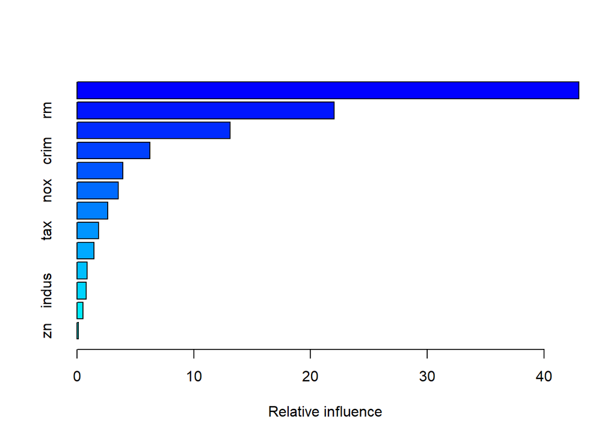

```
##             var    rel.inf
## lstat     lstat 42.9729659
## rm           rm 22.0225424
## dis         dis 13.1314477
## crim       crim  6.2420764
## black     black  3.9156354
## nox         nox  3.5390219
## age         age  2.6260975
## tax         tax  1.8299595
## ptratio ptratio  1.4497597
## chas       chas  0.8610829
## indus     indus  0.7704732
## rad         rad  0.5056271
## zn           zn  0.1333104
```

```r
summary(boost_boston)
```

Yukarıda `summary()` fonksiyonu her bir değişken için göreceli etki istatistiklerini ve grafiğini vermektedir. Buna göre, önceki sonuçlarla uyumlu olarak, `lstat` ve `rm` en önemli değişkenlerdir.

Buna ek olarak değişkenlerin kısmi etkilerini de görselleştirebiliriz:

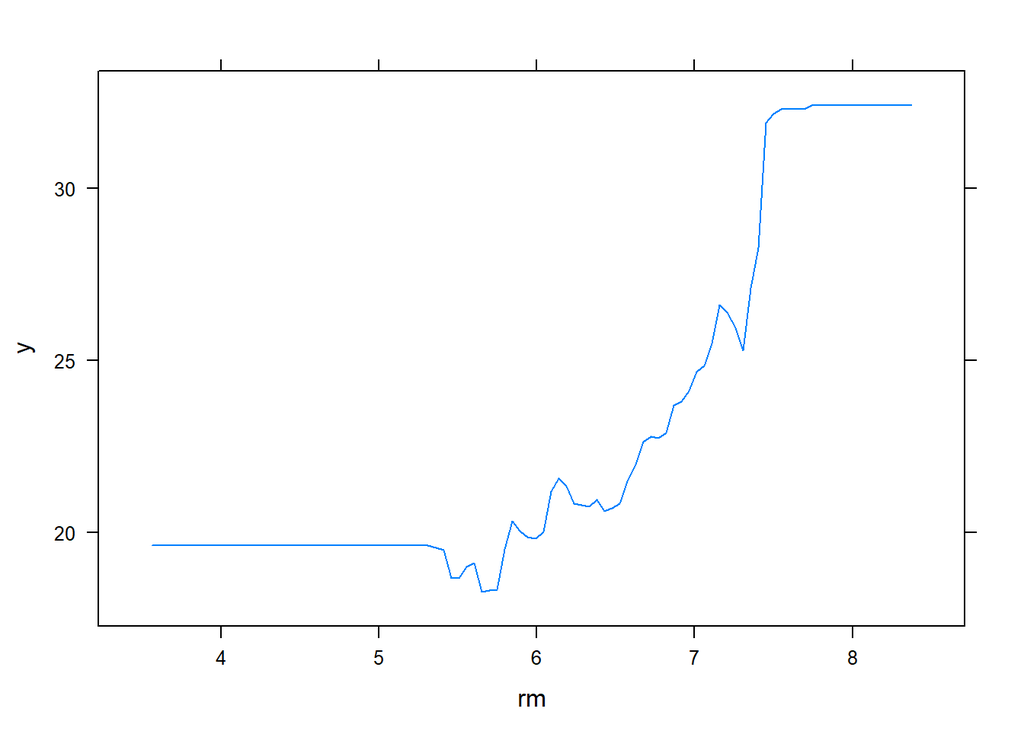

```r
par(mfrow=c(1,2))
plot(boost_boston, i="rm")
```

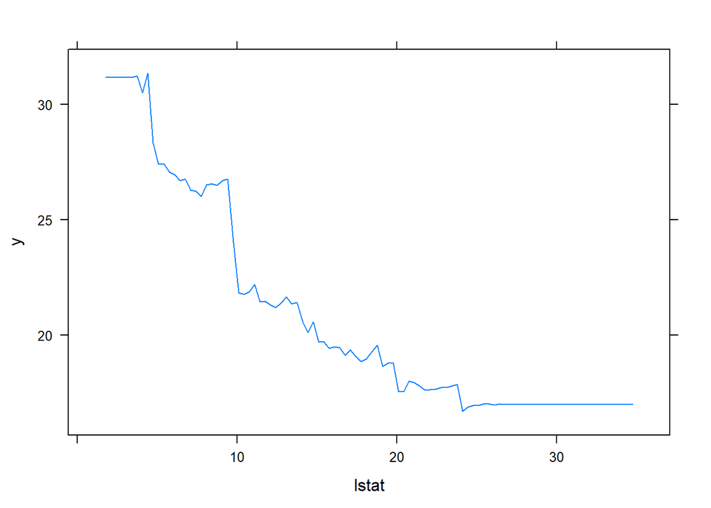

```r
plot(boost_boston, i="lstat")
```

Kısmi bağımlılık grafikleri diğer değişkenlerin etkisi arındırıldıktan sonra bir değişkenin çıktı üzerindeki marjinal etkisini göstermektedir. Buna göre medyan ev fiyatları `rm`’ye göre artarken, `lstat` değişkenine göre azalmaktadır.

Şimdi takviyeli (boosted) ağaç modeline göre `medv` değişkenini test verisinde tahmin edelim

```r
yhat_boost <- predict(boost_boston,
                      newdata = Boston[-train,],
                      n.trees = 5000
                      )
boston_test <- Boston[-train, "medv"]
mean((yhat_boost - boston_test)^2)
```

```
## [1] 11.04542
```

Yukarıda default $\lambda = 0.1$ (küçültme, shrinkage) parametresi kullanıldı. $\lambda=0.2$ için yeniden tahmin edelim:

```r
set.seed(1)
boost_boston <- gbm(medv ~ .,
                    data = Boston[train,],
                    distribution = "gaussian",
                    n.trees=5000,
                    interaction.depth = 4,
                    shrinkage = 0.2,
                    verbose = F
                    )
# kestirimleri test verileriyle hesapla:
yhat_boost <- predict(boost_boston, newdata=Boston[-train,], n.trees=5000)
mean((yhat_boost - boston_test)^2)
```

```
## [1] 12.55007
```

Çapraz geçerleme

```r
# CV
set.seed(1)
boston_boost_cv <- gbm(medv ~ .,
                       data = Boston[train,],
                       distribution = "gaussian",
                       n.trees = 5000,
                       interaction.depth=4,
                       shrinkage = 0.1,
                       verbose = F,
                       cv.folds = 10)

#find the best prediction
best_boost_boston <- gbm.perf(boston_boost_cv)
```

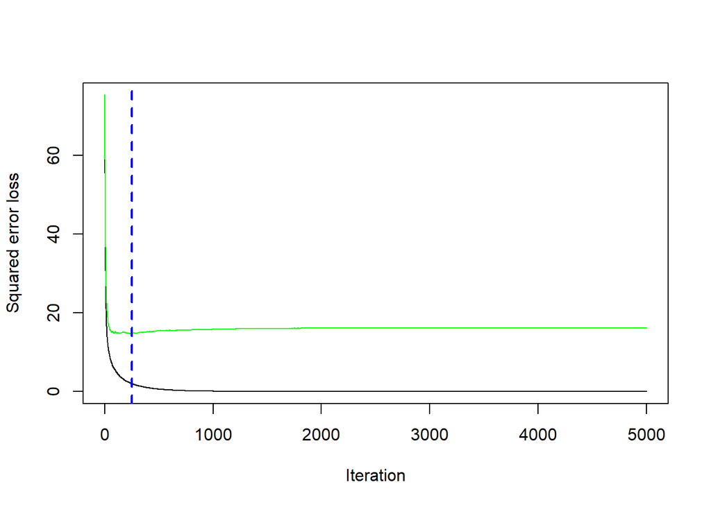

```r
yhat_boost = predict(boston_boost_cv,
                     newdata = Boston[-train,],
                     n.trees = best_boost_boston)
mean((yhat_boost - boston_test)^2)
```

```
## [1] 10.6639
```

## 4.2 `{XGBoost}` Paketi

`{XGBoost}` (eXtreme Gradient Boosting) (bkz. https://cran.r-project.org/web/packages/xgboost/index.html ve https://xgboost.readthedocs.io/en/latest/R-package/xgboostPresentation.html) kütüphanesi gradyan takviye yöntemini uygular.

```r
library(xgboost)
```

```r
# eğitim-test ayırımı (yukarıda yapmıştık)
train_boston <- Boston[train,]
test_boston <- Boston[-train,]
```

`{XGBoost}` paketinde verilerin `xgb.DMatrix` nesnesine dönüştürülmesi gerekir (bu sparse ya da dense matrislere izin verir ve böylece hesaplamalar daha etkin yapılabilir).

```r
# veri matrisini oluştur
data_matrix <- as.matrix(train_boston[!names(train_boston) %in% c("medv")])
#
dtrain <- xgb.DMatrix(data = data_matrix, # kestirim değişkenlerini içeren matris
                      label = train_boston$medv # tepki değişkenini içeren vektör
                      )

xgb_boston <- xgboost(data = dtrain,
                      max_depth = 2,
                      eta = 0.2,
                      nthread = 2,
                      nrounds = 40,
                      lambda = 0,
                      objective = "reg:squarederror")
# test veri matrisini oluştur
dtest <- as.matrix(test_boston[!names(train_boston) %in% c("medv")])
# kestirimleri hesapla
yhat_xgb <- predict(xgb_boston, dtest)
# MSE hesapla
mean((yhat_xgb - test_boston$medv)^2)
```

```
## [1] 11.42741
```

```r
# Çapraz geçerleme ile hiperparametre seçimi
set.seed(123456)
param <- list("max_depth" = 3,
              "eta" = 0.2,
              "objective" = "reg:squarederror",
              "lambda" = 0)
cv_nround <- 500
cv_nfold <- 5
xgb_boston_cv <- xgb.cv(param = param,
                        data = dtrain,
                        nfold = cv_nfold,
                        nrounds = cv_nround,
                        early_stopping_rounds = 200, #
                        verbose = 0)
```

```r
xgb_boston <- xgboost(param = param,
                     data = dtrain,
                     nthread = 2,
                     nrounds = xgb_boston_cv$best_iteration,
                     verbose = 0)
```

```r
yhat_xgb <- predict(xgb_boston, dtest)
mean((yhat_xgb - test_boston$medv)^2)
```

```
## [1] 9.287764
```

```r
importance <- xgb.importance(colnames(train_boston[!names(train_boston) %in% c("medv")]), model=xgb_boston)
importance
```

```
##     Feature         Gain       Cover   Frequency
##  1:   lstat 0.4003006615 0.151969127 0.114206128
##  2:      rm 0.3689041004 0.117356600 0.116991643
##  3:     dis 0.0976156175 0.125889882 0.119777159
##  4:    crim 0.0463530047 0.127927323 0.204735376
##  5:     nox 0.0242060802 0.069920180 0.090529248
##  6:     tax 0.0221532002 0.059888780 0.047353760
##  7:   black 0.0125594872 0.125937822 0.115598886
##  8: ptratio 0.0122063288 0.032551116 0.023676880
##  9:     age 0.0079271800 0.120784295 0.103064067
## 10:   indus 0.0037629738 0.029866488 0.029247911
## 11:     rad 0.0025670152 0.021728709 0.013927577
## 12:      zn 0.0011273393 0.011385700 0.018105850
## 13:    chas 0.0003170114 0.004793979 0.002785515
```

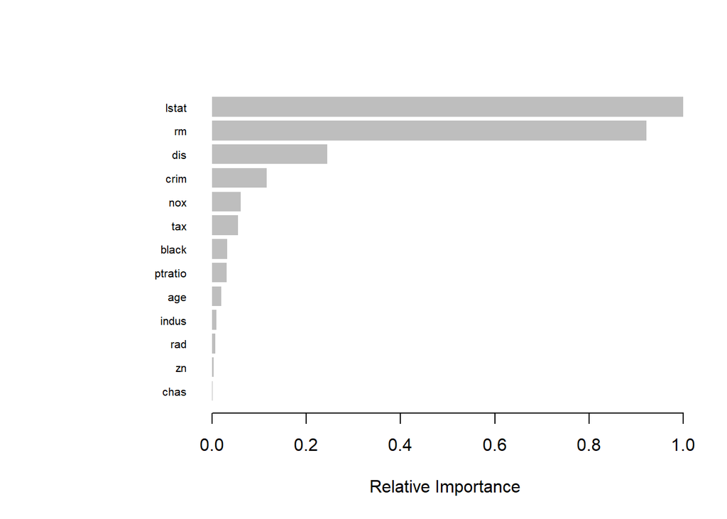

```r
xgb.plot.importance(importance, rel_to_first=TRUE, xlab="Relative Importance")
```

## 4.3 Tidymodels

```r
library(tidyverse)
library(tidymodels)
library(xgboost)
```

```r
# determine training and test sets
# 75% train, 25% test, with stratified sampling based on medv

set.seed(135)
boston_split <- initial_split(Boston, prop=0.75, strata=medv)

boston_train <- boston_split %>% training()

boston_test <- boston_split %>% testing()
```

```r
xgb_spec <- boost_tree(
  trees = 1000,
  tree_depth = tune(), min_n = tune(),
  loss_reduction = tune(),                     ## first three: model complexity
  sample_size = tune(), mtry = tune(),         ## randomness
  learn_rate = tune(),                         ## step size
) %>%
  set_engine("xgboost") %>%
  set_mode("regression")

xgb_spec
```

```
## Boosted Tree Model Specification (regression)
##
## Main Arguments:
##   mtry = tune()
##   trees = 1000
##   min_n = tune()
##   tree_depth = tune()
##   learn_rate = tune()
##   loss_reduction = tune()
##   sample_size = tune()
##
## Computational engine: xgboost
```

```r
# hyperparameter grid
xgb_grid <- grid_latin_hypercube(
  tree_depth(),
  min_n(),
  loss_reduction(),
  sample_size = sample_prop(),
  finalize(mtry(), boston_train[,-14]),
  learn_rate(),
  size = 30
)
xgb_grid
```

```
## # A tibble: 30 x 6
##    tree_depth min_n loss_reduction sample_size  mtry   learn_rate
##         <int> <int>          <dbl>       <dbl> <int>        <dbl>
##  1         14    13       1.05e- 5       0.728     4 0.000127
##  2          1     8       3.26e- 3       0.363     7 0.0000417
##  3          8    22       3.78e- 4       0.321     3 0.000000115
##  4         13     3       5.17e- 3       0.226     8 0.000682
##  5         12    13       9.30e- 7       0.561     1 0.0858
##  6          7    35       1.01e-10       0.479    12 0.0000000864
##  7          4     9       4.38e- 8       0.864     6 0.000000213
##  8         12    23       7.78e- 6       0.383     6 0.0287
##  9          5    20       2.35e+ 1       0.921     2 0.00390
## 10          9    25       5.76e- 2       0.686    10 0.00000428
## # ... with 20 more rows
```

```r
xgb_wf <- workflow() %>%
  add_formula(medv ~ .) %>%
  add_model(xgb_spec)

xgb_wf
```

```
## == Workflow ====================================================================
## Preprocessor: Formula
## Model: boost_tree()
##
## -- Preprocessor ----------------------------------------------------------------
## medv ~ .
##
## -- Model -----------------------------------------------------------------------
## Boosted Tree Model Specification (regression)
##
## Main Arguments:
##   mtry = tune()
##   trees = 1000
##   min_n = tune()
##   tree_depth = tune()
##   learn_rate = tune()
##   loss_reduction = tune()
##   sample_size = tune()
##
## Computational engine: xgboost
```

```r
# CV folds
set.seed(123)
boston_folds <- vfold_cv(boston_train, v = 5, strata = medv)

boston_folds
```

```
## #  5-fold cross-validation using stratification
## # A tibble: 5 x 2
##   splits           id
##   <list>           <chr>
## 1 <split [303/78]> Fold1
## 2 <split [304/77]> Fold2
## 3 <split [305/76]> Fold3
## 4 <split [306/75]> Fold4
## 5 <split [306/75]> Fold5
```

```r
library(doParallel)
doParallel::registerDoParallel()

set.seed(234)
xgb_res <- tune_grid(
  xgb_wf,
  resamples = boston_folds,
  grid = xgb_grid,
  control = control_grid(save_pred = TRUE)
)

xgb_res
```

```
## # Tuning results
## # 5-fold cross-validation using stratification
## # A tibble: 5 x 5
##   splits        id    .metrics            .notes           .predictions
##   <list>        <chr> <list>              <list>           <list>
## 1 <split [303/~ Fold1 <tibble[,10] [60 x~ <tibble[,1] [1 ~ <tibble[,10] [2,340 ~
## 2 <split [304/~ Fold2 <tibble[,10] [60 x~ <tibble[,1] [1 ~ <tibble[,10] [2,310 ~
## 3 <split [305/~ Fold3 <tibble[,10] [60 x~ <tibble[,1] [1 ~ <tibble[,10] [2,280 ~
## 4 <split [306/~ Fold4 <tibble[,10] [60 x~ <tibble[,1] [1 ~ <tibble[,10] [2,250 ~
## 5 <split [306/~ Fold5 <tibble[,10] [60 x~ <tibble[,1] [1 ~ <tibble[,10] [2,250 ~
```

```r
collect_metrics(xgb_res)
```

```
## # A tibble: 60 x 12
##     mtry min_n tree_depth  learn_rate loss_reduction sample_size .metric
##    <int> <int>      <int>       <dbl>          <dbl>       <dbl> <chr>
##  1     4    13         14 0.000127       0.0000105         0.728 rmse
##  2     4    13         14 0.000127       0.0000105         0.728 rsq
##  3     7     8          1 0.0000417      0.00326           0.363 rmse
##  4     7     8          1 0.0000417      0.00326           0.363 rsq
##  5     3    22          8 0.000000115    0.000378          0.321 rmse
##  6     3    22          8 0.000000115    0.000378          0.321 rsq
##  7     8     3         13 0.000682       0.00517           0.226 rmse
##  8     8     3         13 0.000682       0.00517           0.226 rsq
##  9     1    13         12 0.0858         0.000000930       0.561 rmse
## 10     1    13         12 0.0858         0.000000930       0.561 rsq
## # ... with 50 more rows, and 5 more variables: .estimator <chr>, mean <dbl>,
## #   n <int>, std_err <dbl>, .config <chr>
```

```r
xgb_res %>% collect_metrics(summarize=FALSE)
```

```
## # A tibble: 300 x 11
##    id     mtry min_n tree_depth learn_rate loss_reduction sample_size .metric
##    <chr> <int> <int>      <int>      <dbl>          <dbl>       <dbl> <chr>
##  1 Fold1     4    13         14   0.000127      0.0000105       0.728 rmse
##  2 Fold1     4    13         14   0.000127      0.0000105       0.728 rsq
##  3 Fold2     4    13         14   0.000127      0.0000105       0.728 rmse
##  4 Fold2     4    13         14   0.000127      0.0000105       0.728 rsq
##  5 Fold3     4    13         14   0.000127      0.0000105       0.728 rmse
##  6 Fold3     4    13         14   0.000127      0.0000105       0.728 rsq
##  7 Fold4     4    13         14   0.000127      0.0000105       0.728 rmse
##  8 Fold4     4    13         14   0.000127      0.0000105       0.728 rsq
##  9 Fold5     4    13         14   0.000127      0.0000105       0.728 rmse
## 10 Fold5     4    13         14   0.000127      0.0000105       0.728 rsq
## # ... with 290 more rows, and 3 more variables: .estimator <chr>,
## #   .estimate <dbl>, .config <chr>
```

```r
xgb_res %>%
  collect_metrics(summarize = FALSE) %>%
  filter(.metric == 'rmse') %>%
  group_by(id) %>%
  summarize(min_rmse = min(.estimate),
            median_rmse = median(.estimate),
            max_rmse = max(.estimate))
```

```
## # A tibble: 5 x 4
##   id    min_rmse median_rmse max_rmse
##   <chr>    <dbl>       <dbl>    <dbl>
## 1 Fold1     3.32        23.2     23.2
## 2 Fold2     3.23        23.4     23.5
## 3 Fold3     3.45        23.7     23.8
## 4 Fold4     3.44        24.4     24.5
## 5 Fold5     5.23        24.1     24.2
```

```r
xgb_res %>%
  show_best(metric = 'rmse', n = 5)
```

```
## # A tibble: 5 x 12
##    mtry min_n tree_depth learn_rate loss_reduction sample_size .metric
##   <int> <int>      <int>      <dbl>          <dbl>       <dbl> <chr>
## 1     1    13         12    0.0858     0.000000930       0.561 rmse
## 2     9    17         10    0.00916    1.51              0.592 rmse
## 3     8    37          2    0.0140     0.0712            0.982 rmse
## 4     6    23         12    0.0287     0.00000778        0.383 rmse
## 5     2    20          5    0.00390   23.5               0.921 rmse
## # ... with 5 more variables: .estimator <chr>, mean <dbl>, n <int>,
## #   std_err <dbl>, .config <chr>
```

```r
xgb_res %>%
  show_best(metric = 'rsq', n = 5)
```

```
## # A tibble: 5 x 12
##    mtry min_n tree_depth learn_rate loss_reduction sample_size .metric
##   <int> <int>      <int>      <dbl>          <dbl>       <dbl> <chr>
## 1     1    13         12    0.0858     0.000000930       0.561 rsq
## 2     9    17         10    0.00916    1.51              0.592 rsq
## 3     8    37          2    0.0140     0.0712            0.982 rsq
## 4     6     6         14    0.00129    0.0129            0.771 rsq
## 5     6    23         12    0.0287     0.00000778        0.383 rsq
## # ... with 5 more variables: .estimator <chr>, mean <dbl>, n <int>,
## #   std_err <dbl>, .config <chr>
```

```r
best_xgb_model <- xgb_res %>%
  select_best(metric = 'rmse')
best_xgb_model
```

```
## # A tibble: 1 x 7
##    mtry min_n tree_depth learn_rate loss_reduction sample_size .config
##   <int> <int>      <int>      <dbl>          <dbl>       <dbl> <chr>
## 1     1    13         12     0.0858    0.000000930       0.561 Preprocessor1_Mo~
```

```r
# finalize the workflow (fixes the hyperparameters)
final_boston_wkfl <- xgb_wf %>%
  finalize_workflow(best_xgb_model)
final_boston_wkfl
```

```
## == Workflow ====================================================================
## Preprocessor: Formula
## Model: boost_tree()
##
## -- Preprocessor ----------------------------------------------------------------
## medv ~ .
##
## -- Model -----------------------------------------------------------------------
## Boosted Tree Model Specification (regression)
##
## Main Arguments:
##   mtry = 1
##   trees = 1000
##   min_n = 13
##   tree_depth = 12
##   learn_rate = 0.085823042243491
##   loss_reduction = 9.29838406371628e-07
##   sample_size = 0.56078905938426
##
## Computational engine: xgboost
```

```r
# train the decision tree
boston_final_fit <- final_boston_wkfl %>%
  last_fit(split = boston_split)
boston_final_fit %>%
  collect_metrics()
```

```
## # A tibble: 2 x 4
##   .metric .estimator .estimate .config
##   <chr>   <chr>          <dbl> <chr>
## 1 rmse    standard       3.04  Preprocessor1_Model1
## 2 rsq     standard       0.894 Preprocessor1_Model1
```

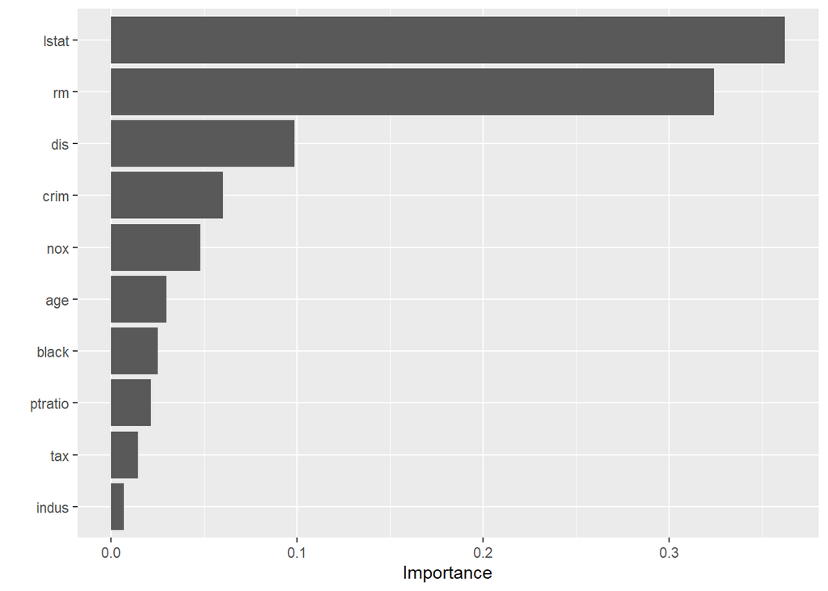

```r
# variable importance plots
library(vip)

boston_final_fit %>%
  pluck(".workflow", 1) %>%
  pull_workflow_fit() %>%
  vip(num_features = 10)
```

# 5 Örnek: Titanic

Bu örnekte Titanic kazasında hayatını kaybedenler için bir sınıflandırma ağacı oluşturmaya çalışacağız (detaylar için bkz. [RMS Titanic](https://en.wikipedia.org/wiki/RMS_Titanic) ). Bu trajik kaza çok fazla kişinin ölümü ile sonuçlanmıştır. Böyle kazaların tekrar yaşanmaması için çok sayıda güvenlik tedbirlerinin alınmasında ve yasal düzenleme yapılmasında etkili olmuştur.

Sorular: acaba bu kadar kişinin ölümünün ardındaki nedenler nelerdir? Hangi değişkenler bireyin hayatta kalma olasılığı üzerinde önemli bir etkiye sahiptir?

Önce verileri `R`’a tanıtalım:

```r
library(tidyverse)
library(modelr)
library(broom)
set.seed(1234)

theme_set(theme_minimal())

library(titanic)
# use the training data
titanic <- titanic_train %>%
  as_tibble()

titanic %>%
  head() %>%
  knitr::kable()
```

| PassengerId | Survived | Pclass | Name | Sex | Age | SibSp | Parch | Ticket | Fare | Cabin | Embarked |
| --- | --- | --- | --- | --- | --- | --- | --- | --- | --- | --- | --- |
| 1 | 0 | 3 | Braund, Mr. Owen Harris | male | 22 | 1 | 0 | A/5 21171 | 7.2500 |  | S |
| 2 | 1 | 1 | Cumings, Mrs. John Bradley (Florence Briggs Thayer) | female | 38 | 1 | 0 | PC 17599 | 71.2833 | C85 | C |
| 3 | 1 | 3 | Heikkinen, Miss. Laina | female | 26 | 0 | 0 | STON/O2. 3101282 | 7.9250 |  | S |
| 4 | 1 | 1 | Futrelle, Mrs. Jacques Heath (Lily May Peel) | female | 35 | 1 | 0 | 113803 | 53.1000 | C123 | S |
| 5 | 0 | 3 | Allen, Mr. William Henry | male | 35 | 0 | 0 | 373450 | 8.0500 |  | S |
| 6 | 0 | 3 | Moran, Mr. James | male | NA | 0 | 0 | 330877 | 8.4583 |  | Q |

Çıktı değişkenini oluştur:

```r
titanic_tree_data <- titanic %>%
  mutate(Survived = if_else(Survived == 1, "Survived", "Died"),
         Survived = as.factor(Survived),
         Sex = as.factor(Sex))
titanic_tree_data
```

```
## # A tibble: 891 x 12
##    PassengerId Survived Pclass Name   Sex     Age SibSp Parch Ticket  Fare Cabin
##          <int> <fct>     <int> <chr>  <fct> <dbl> <int> <int> <chr>  <dbl> <chr>
##  1           1 Died          3 Braun~ male     22     1     0 A/5 2~  7.25 ""
##  2           2 Survived      1 Cumin~ fema~    38     1     0 PC 17~ 71.3  "C85"
##  3           3 Survived      3 Heikk~ fema~    26     0     0 STON/~  7.92 ""
##  4           4 Survived      1 Futre~ fema~    35     1     0 113803 53.1  "C12~
##  5           5 Died          3 Allen~ male     35     0     0 373450  8.05 ""
##  6           6 Died          3 Moran~ male     NA     0     0 330877  8.46 ""
##  7           7 Died          1 McCar~ male     54     0     0 17463  51.9  "E46"
##  8           8 Died          3 Palss~ male      2     3     1 349909 21.1  ""
##  9           9 Survived      3 Johns~ fema~    27     0     2 347742 11.1  ""
## 10          10 Survived      2 Nasse~ fema~    14     1     0 237736 30.1  ""
## # ... with 881 more rows, and 1 more variable: Embarked <chr>
```

```r
table(titanic_tree_data$Survived)
```

```
##
##     Died Survived
##      549      342
```

Sadece `age` ve `sex` özniteliklerini kullanarak küçük bir ağaç tahmin edelim. Bunun için `partykit` paketini kullanacağız:

```r
library(partykit)
titanic_tree <- ctree(Survived ~ Age + Sex, data = titanic_tree_data)
titanic_tree
```

```
##
## Model formula:
## Survived ~ Age + Sex
##
## Fitted party:
## [1] root
## |   [2] Sex in female: Survived (n = 314, err = 25.8%)
## |   [3] Sex in male
## |   |   [4] Age <= 6: Survived (n = 35, err = 48.6%)
## |   |   [5] Age > 6: Died (n = 542, err = 16.8%)
##
## Number of inner nodes:    2
## Number of terminal nodes: 3
```

Oluşturduğumuz ağaç 3 son düğüme (yaprak) ve 2 iç düğüme sahiptir. Ağacın görselleştirilmesi:

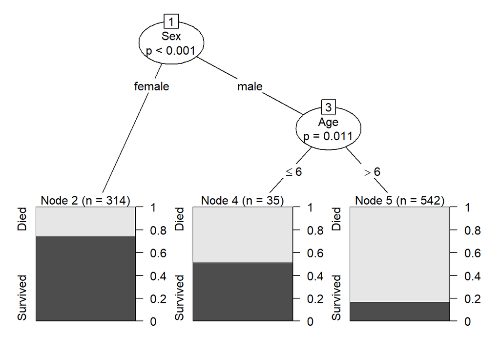

```r
plot(titanic_tree)
```

Sınıflandırma hatası:

```r
# compute predicted values
pred1 <- predict(titanic_tree)
# true classifications
predsuccess1 <- (pred1 == titanic_tree_data$Survived)
# wrong classifications
prederror1 <- !predsuccess1
# average misclassification rate:
mean(prederror1, na.rm = TRUE)
```

```
## [1] 0.2121212
```

```r
# or just in one line:
# 1 - mean(predict(titanic_tree) == titanic_tree_data$Survived, na.rm = TRUE)
```

Bu basit ağaçla bile hata oranı yaklaşık % 21 olarak bulundu.

Veri setinde yer alan diğer öznitelikleri de kullanarak daha karmaşık bir ağaç tahmin edelim. Önce karakter değişkenleri faktör değişkenine dönüştürelim:

```r
titanic_tree_full_data <- titanic %>%
  mutate(Survived = if_else(Survived == 1, "Survived",
                            if_else(Survived == 0, "Died", NA_character_))) %>%
  mutate_if(is.character, as.factor)
```

Ağacı tahmin et:

```r
titanic_tree_full <- ctree(Survived ~ Pclass + Sex + Age + SibSp +
                             Parch + Fare + Embarked,
                           data = titanic_tree_full_data)
titanic_tree_full
```

```
##
## Model formula:
## Survived ~ Pclass + Sex + Age + SibSp + Parch + Fare + Embarked
##
## Fitted party:
## [1] root
## |   [2] Sex in female
## |   |   [3] Pclass <= 2: Survived (n = 170, err = 5.3%)
## |   |   [4] Pclass > 2
## |   |   |   [5] Fare <= 23.25: Survived (n = 117, err = 41.0%)
## |   |   |   [6] Fare > 23.25: Died (n = 27, err = 11.1%)
## |   [7] Sex in male
## |   |   [8] Pclass <= 1
## |   |   |   [9] Age <= 52: Died (n = 98, err = 41.8%)
## |   |   |   [10] Age > 52: Died (n = 24, err = 16.7%)
## |   |   [11] Pclass > 1
## |   |   |   [12] Age <= 9
## |   |   |   |   [13] Pclass <= 2: Survived (n = 12, err = 25.0%)
## |   |   |   |   [14] Pclass > 2: Died (n = 29, err = 31.0%)
## |   |   |   [15] Age > 9: Died (n = 414, err = 11.1%)
##
## Number of inner nodes:    7
## Number of terminal nodes: 8
```

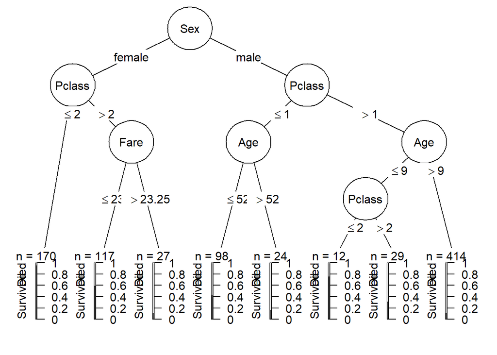

```r
plot(titanic_tree_full,  ip_args = list(pval = FALSE, id = FALSE),
     tp_args = list( id = FALSE) )
```

Hata oranı:

```r
# error rate
1 - mean(predict(titanic_tree_full) == titanic_tree_data$Survived,
         na.rm = TRUE)
```

```
## [1] 0.1829405
```

Hata oranı daha da düştü, %18.3.

Şimdi `caret` paketini kullanarak bir rassal orman tahmin edelim. Bunun için `caret::train()` fonksiyonunu kullanacağız:

```r
# drop the NA obs.
titanic_rf_data <- titanic_tree_full_data %>%
  select(Survived, Pclass, Sex, Age, SibSp, Parch, Fare, Embarked) %>%
  drop_na()
titanic_rf_data
```

```
## # A tibble: 714 x 8
##    Survived Pclass Sex      Age SibSp Parch  Fare Embarked
##    <fct>     <int> <fct>  <dbl> <int> <int> <dbl> <fct>
##  1 Died          3 male      22     1     0  7.25 S
##  2 Survived      1 female    38     1     0 71.3  C
##  3 Survived      3 female    26     0     0  7.92 S
##  4 Survived      1 female    35     1     0 53.1  S
##  5 Died          3 male      35     0     0  8.05 S
##  6 Died          1 male      54     0     0 51.9  S
##  7 Died          3 male       2     3     1 21.1  S
##  8 Survived      3 female    27     0     2 11.1  S
##  9 Survived      2 female    14     1     0 30.1  C
## 10 Survived      3 female     4     1     1 16.7  S
## # ... with 704 more rows
```

```r
# build a random forest with ntree=200
library(caret)
titanic_rf <- train(Survived ~ ., data = titanic_rf_data,
                    method = "rf",
                    ntree = 200,
                    trControl = trainControl(method = "oob"))
titanic_rf
```

```
## Random Forest
##
## 714 samples
##   7 predictor
##   2 classes: 'Died', 'Survived'
##
## No pre-processing
## Resampling results across tuning parameters:
##
##   mtry  Accuracy   Kappa
##   2     0.8067227  0.5871864
##   5     0.8081232  0.5976323
##   9     0.7997199  0.5813948
##
## Accuracy was used to select the optimal model using the largest value.
## The final value used for the model was mtry = 5.
```

```r
str(titanic_rf, max.level = 1)
```

```
## List of 24
##  $ method      : chr "rf"
##  $ modelInfo   :List of 15
##  $ modelType   : chr "Classification"
##  $ results     :'data.frame':    3 obs. of  3 variables:
##  $ pred        : NULL
##  $ bestTune    :'data.frame':    1 obs. of  1 variable:
##  $ call        : language train.formula(form = Survived ~ ., data = titanic_rf_data, method = "rf",      ntree = 200, trControl = trainCont| __truncated__
##  $ dots        :List of 1
##  $ metric      : chr "Accuracy"
##  $ control     :List of 26
##  $ finalModel  :List of 23
##   ..- attr(*, "class")= chr "randomForest"
##  $ preProcess  : NULL
##  $ trainingData: tibble[,8] [714 x 8] (S3: tbl_df/tbl/data.frame)
##  $ resample    : NULL
##  $ resampledCM : NULL
##  $ perfNames   : chr [1:2] "Accuracy" "Kappa"
##  $ maximize    : logi TRUE
##  $ yLimits     : NULL
##  $ times       :List of 3
##  $ levels      : chr [1:2] "Died" "Survived"
##   ..- attr(*, "ordered")= logi FALSE
##  $ terms       :Classes 'terms', 'formula'  language Survived ~ Pclass + Sex + Age + SibSp + Parch + Fare + Embarked
##   .. ..- attr(*, "variables")= language list(Survived, Pclass, Sex, Age, SibSp, Parch, Fare, Embarked)
##   .. ..- attr(*, "factors")= int [1:8, 1:7] 0 1 0 0 0 0 0 0 0 0 ...
##   .. .. ..- attr(*, "dimnames")=List of 2
##   .. ..- attr(*, "term.labels")= chr [1:7] "Pclass" "Sex" "Age" "SibSp" ...
##   .. ..- attr(*, "order")= int [1:7] 1 1 1 1 1 1 1
##   .. ..- attr(*, "intercept")= int 1
##   .. ..- attr(*, "response")= int 1
##   .. ..- attr(*, ".Environment")=<environment: R_GlobalEnv>
##   .. ..- attr(*, "predvars")= language list(Survived, Pclass, Sex, Age, SibSp, Parch, Fare, Embarked)
##   .. ..- attr(*, "dataClasses")= Named chr [1:8] "factor" "numeric" "factor" "numeric" ...
##   .. .. ..- attr(*, "names")= chr [1:8] "Survived" "Pclass" "Sex" "Age" ...
##  $ coefnames   : chr [1:9] "Pclass" "Sexmale" "Age" "SibSp" ...
##  $ contrasts   :List of 2
##  $ xlevels     :List of 2
##  - attr(*, "class")= chr [1:2] "train" "train.formula"
```

```r
# Info on the final model:
titanic_rf$finalModel
```

```
##
## Call:
##  randomForest(x = x, y = y, ntree = 200, mtry = param$mtry)
##                Type of random forest: classification
##                      Number of trees: 200
## No. of variables tried at each split: 5
##
##         OOB estimate of  error rate: 19.61%
## Confusion matrix:
##          Died Survived class.error
## Died      366       58   0.1367925
## Survived   82      208   0.2827586
```

```r
# confusion table
knitr::kable(titanic_rf$finalModel$confusion)
```

|  | Died | Survived | class.error |
| --- | --- | --- | --- |
| Died | 366 | 58 | 0.1367925 |
| Survived | 82 | 208 | 0.2827586 |

```r
# look at an individual tree
randomForest::getTree(titanic_rf$finalModel, labelVar = TRUE)
```

```
##     left daughter right daughter split var split point status prediction
## 1               2              3    Pclass     2.50000      1       <NA>
## 2               4              5      Fare    13.25000      1       <NA>
## 3               6              7 EmbarkedC     0.50000      1       <NA>
## 4               8              9    Pclass     1.50000      1       <NA>
## 5              10             11   Sexmale     0.50000      1       <NA>
## 6              12             13   Sexmale     0.50000      1       <NA>
## 7              14             15     SibSp     1.50000      1       <NA>
## 8               0              0      <NA>     0.00000     -1       Died
## 9              16             17     SibSp     0.50000      1       <NA>
## 10             18             19       Age     3.00000      1       <NA>
## 11             20             21       Age    17.50000      1       <NA>
## 12             22             23      Fare    17.70000      1       <NA>
## 13             24             25       Age     9.50000      1       <NA>
## 14             26             27      Fare    15.49375      1       <NA>
```

[output cut: 183 more lines]

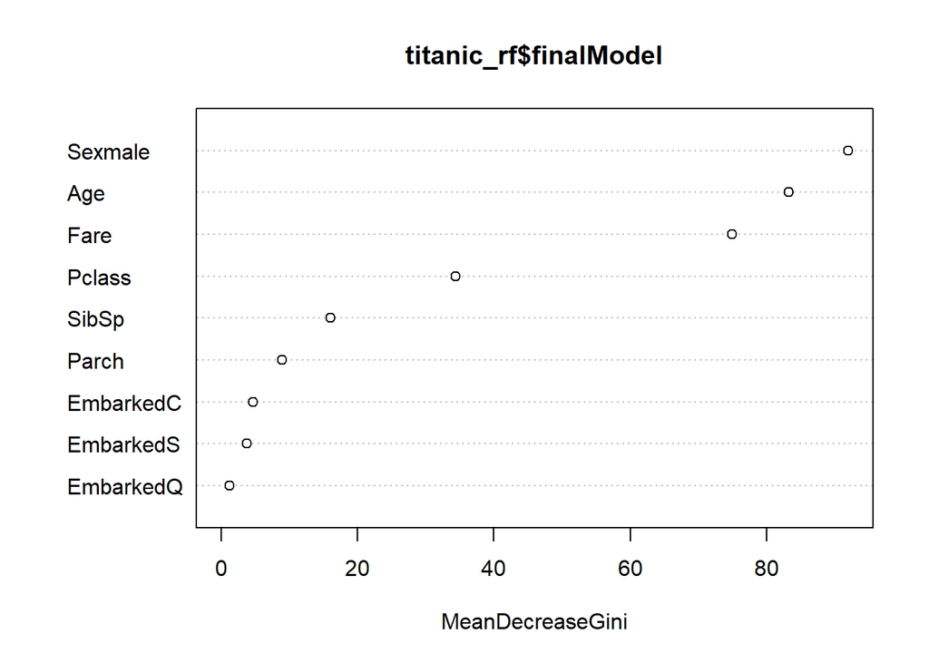

```r
# var importance plot
randomForest::varImpPlot(titanic_rf$finalModel)
```